# GH1033102 AI Final Project

[figure not shown]

```python
from IPython.display import Image
Image(filename='C:/Users/darshan gangappa/Pictures/Screenshots/Screenshot 2024-09-24 183823.png')
```

**Title: "Data Cleaning and Analysis of US airline flight routes and fares from the year 1993 to 2024 "**

**Introduction**

The datasets which you have provided contain a structural data of US airline flight routes and fares from the year 1993 to 2024. It is made up of several indexes relating to flight connections, fares, airlines, as well as passengers’ traffic between different cities. Here we provide an introduction and the explanation of major fields in the dataset.

This dataset is about U. S. airline industry and can help to provide information on aspects as flight routes, fares and passengers for several decades. It is useful for evaluating the shift in the approach to ticket pricing, passengers’ behavior and the wars between full-service and LCC competitors. It has a wide temporal coverage and ranges from 1993 to 2024 which is useful in studying the technical changes that has occurred within the airline industry.

# url for the data set: https://www.kaggle.com/datasets/bhavikjikadara/us-airline-flight-routes-and-fares-1993-2024

```python
import pandas            as pd
import numpy             as np
import matplotlib.pyplot as plt
import seaborn           as sns
import warnings
import matplotlib.animation as animation
import matplotlib.ticker as ticker

from IPython.display import HTML
```

```python
df = pd.read_csv("C:/Users/darshan gangappa/Desktop/AI notes/US Airline Flight Routes and Fares 1993-2024.csv")
print(df.shape)
print()
display(df.head())
```

```
(245955, 21)
```

|  | tbl | Year | quarter | citymarketid_1 | citymarketid_2 | city1 | city2 | airportid_1 | airportid_2 | airport_1 | ... | nsmiles | passengers | fare | carrier_lg | large_ms | fare_lg | carrier_low | lf_ms | fare_low | tbl1apk |
| --- | --- | --- | --- | --- | --- | --- | --- | --- | --- | --- | --- | --- | --- | --- | --- | --- | --- | --- | --- | --- | --- |
| 0 | Table1a | 2021 | 3 | 30135 | 33195 | Allentown/Bethlehem/Easton, PA | Tampa, FL (Metropolitan Area) | 10135 | 14112 | ABE | ... | 970 | 180 | 81.43 | G4 | 1.0000 | 81.43 | G4 | 1.0000 | 81.43 | 202131013514112ABEPIE |
| 1 | Table1a | 2021 | 3 | 30135 | 33195 | Allentown/Bethlehem/Easton, PA | Tampa, FL (Metropolitan Area) | 10135 | 15304 | ABE | ... | 970 | 19 | 208.93 | DL | 0.4659 | 219.98 | UA | 0.1193 | 154.11 | 202131013515304ABETPA |
| 2 | Table1a | 2021 | 3 | 30140 | 30194 | Albuquerque, NM | Dallas/Fort Worth, TX | 10140 | 11259 | ABQ | ... | 580 | 204 | 184.56 | WN | 0.9968 | 184.44 | WN | 0.9968 | 184.44 | 202131014011259ABQDAL |
| 3 | Table1a | 2021 | 3 | 30140 | 30194 | Albuquerque, NM | Dallas/Fort Worth, TX | 10140 | 11298 | ABQ | ... | 580 | 264 | 182.64 | AA | 0.9774 | 183.09 | AA | 0.9774 | 183.09 | 202131014011298ABQDFW |
| 4 | Table1a | 2021 | 3 | 30140 | 30466 | Albuquerque, NM | Phoenix, AZ | 10140 | 14107 | ABQ | ... | 328 | 398 | 177.11 | WN | 0.6061 | 184.49 | AA | 0.3939 | 165.77 | 202131014014107ABQPHX |

5 rows × 21 columns

```python
df.info()
```

```
<class 'pandas.core.frame.DataFrame'>
RangeIndex: 245955 entries, 0 to 245954
Data columns (total 21 columns):
 #   Column          Non-Null Count   Dtype
---  ------          --------------   -----
 0   tbl             245955 non-null  object
 1   Year            245955 non-null  int64
 2   quarter         245955 non-null  int64
 3   citymarketid_1  245955 non-null  int64
 4   citymarketid_2  245955 non-null  int64
 5   city1           245955 non-null  object
 6   city2           245955 non-null  object
 7   airportid_1     245955 non-null  int64
 8   airportid_2     245955 non-null  int64
 9   airport_1       245955 non-null  object
 10  airport_2       245955 non-null  object
 11  nsmiles         245955 non-null  int64
 12  passengers      245955 non-null  int64
 13  fare            245955 non-null  float64
 14  carrier_lg      244415 non-null  object
 15  large_ms        244415 non-null  float64
 16  fare_lg         244415 non-null  float64
 17  carrier_low     244343 non-null  object
 18  lf_ms           244343 non-null  float64
 19  fare_low        244343 non-null  float64
 20  tbl1apk         245955 non-null  object
dtypes: float64(5), int64(8), object(8)
memory usage: 39.4+ MB
```

```python
df.describe().T
```

|  | count | mean | std | min | 25% | 50% | 75% | max |
| --- | --- | --- | --- | --- | --- | --- | --- | --- |
| Year | 245955.0 | 2008.524124 | 8.703364 | 1993.0000 | 2001.000 | 2008.0000 | 2016.0000 | 2024.0 |
| quarter | 245955.0 | 2.479153 | 1.122149 | 1.0000 | 1.000 | 2.0000 | 3.0000 | 4.0 |
| citymarketid_1 | 245955.0 | 31556.430201 | 1089.872880 | 30135.0000 | 30721.000 | 31423.0000 | 32467.0000 | 35412.0 |
| citymarketid_2 | 245955.0 | 32180.117086 | 1232.464184 | 30189.0000 | 30994.000 | 32211.0000 | 33192.0000 | 35628.0 |
| airportid_1 | 245955.0 | 12437.099986 | 1431.665257 | 10135.0000 | 11193.000 | 12266.0000 | 13487.0000 | 16440.0 |
| airportid_2 | 245955.0 | 13249.889525 | 1425.810159 | 10466.0000 | 12197.000 | 13303.0000 | 14679.0000 | 15919.0 |
| nsmiles | 245955.0 | 1189.812319 | 703.143472 | 109.0000 | 626.000 | 1023.0000 | 1736.0000 | 2724.0 |
| passengers | 245955.0 | 299.476795 | 511.389486 | 0.0000 | 21.000 | 113.0000 | 339.0000 | 8301.0 |
| fare | 245955.0 | 218.979587 | 82.372486 | 50.0000 | 164.620 | 209.3200 | 262.8900 | 3377.0 |
| large_ms | 244415.0 | 0.665252 | 0.224635 | 0.0038 | 0.480 | 0.6524 | 0.8719 | 1.0 |
| fare_lg | 244415.0 | 218.710963 | 84.674363 | 50.0000 | 161.500 | 208.0300 | 263.6400 | 2725.6 |
| lf_ms | 244343.0 | 0.450438 | 0.332669 | 0.0100 | 0.158 | 0.3600 | 0.7500 | 1.0 |
| fare_low | 244343.0 | 190.675939 | 73.577694 | 50.0000 | 140.060 | 181.6300 | 230.0400 | 2725.6 |

```python
display(df.isnull().sum())
```

```
tbl                  0
Year                 0
quarter              0
citymarketid_1       0
citymarketid_2       0
city1                0
city2                0
airportid_1          0
airportid_2          0
airport_1            0
airport_2            0
nsmiles              0
passengers           0
fare                 0
carrier_lg        1540
large_ms          1540
fare_lg           1540
carrier_low       1612
lf_ms             1612
fare_low          1612
tbl1apk              0
dtype: int64
```

```python
df.isnull().sum().sum()
```

```
9456
```

```python
# Identify numerical and categorical columns separately
numerical_cols = df.select_dtypes(include=['float64', 'int64']).columns
categorical_cols = df.select_dtypes(include=['object']).columns

# Impute missing values for numerical columns with median
for col in numerical_cols:
    if df[col].isnull().sum() > 0:
        df[col].fillna(df[col].median(), inplace=True)

# Impute missing values for categorical columns with mode
for col in categorical_cols:
    if df[col].isnull().sum() > 0:
        df[col].fillna(df[col].mode()[0], inplace=True)

# Display missing values after imputation to verify
print("\nMissing values after imputation:")
print(df.isnull().sum())

df.shape
```

```
Missing values after imputation:
tbl               0
Year              0
quarter           0
citymarketid_1    0
citymarketid_2    0
city1             0
city2             0
airportid_1       0
airportid_2       0
airport_1         0
airport_2         0
nsmiles           0
passengers        0
fare              0
carrier_lg        0
large_ms          0
fare_lg           0
carrier_low       0
lf_ms             0
fare_low          0
tbl1apk           0
dtype: int64
```

```
(245955, 21)
```

```python
print(df.dtypes)
```

```
tbl                object
Year                int64
quarter             int64
citymarketid_1      int64
citymarketid_2      int64
city1              object
city2              object
airportid_1         int64
airportid_2         int64
airport_1          object
airport_2          object
nsmiles             int64
passengers          int64
fare              float64
carrier_lg         object
large_ms          float64
fare_lg           float64
carrier_low        object
lf_ms             float64
fare_low          float64
tbl1apk            object
dtype: object
```

**Exploratory Data Analysis**

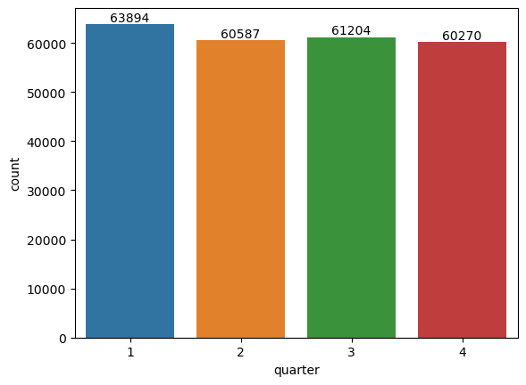

```python
# plotting a bar chart for quater and it's count

ax = sns.countplot(x = 'quarter',data = df)

for bars in ax.containers:
    ax.bar_label(bars)
```

[output not shown]

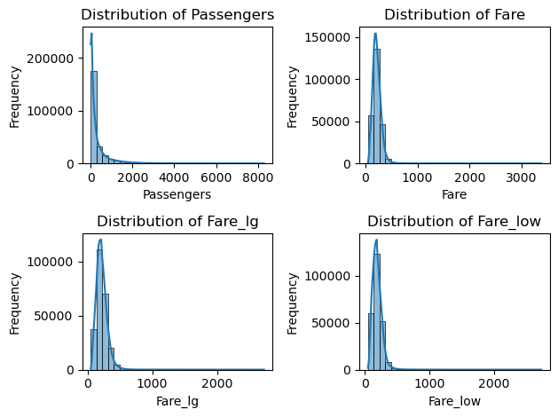

```python
df.replace([np.inf, -np.inf], np.nan, inplace=True)

numeric_cols = ['passengers', 'fare', 'fare_lg', 'fare_low']

# Loop through numeric columns and create histograms
for i, col in enumerate(numeric_cols, 1):
    plt.subplot(2, 2, i)  # 2 rows, 2 columns for the grid of charts
    sns.histplot(df[col], kde=True, bins=30)
    plt.title(f'Distribution of {col.capitalize()}')
    plt.xlabel(col.capitalize())
    plt.ylabel('Frequency')

plt.tight_layout()
plt.show()
```

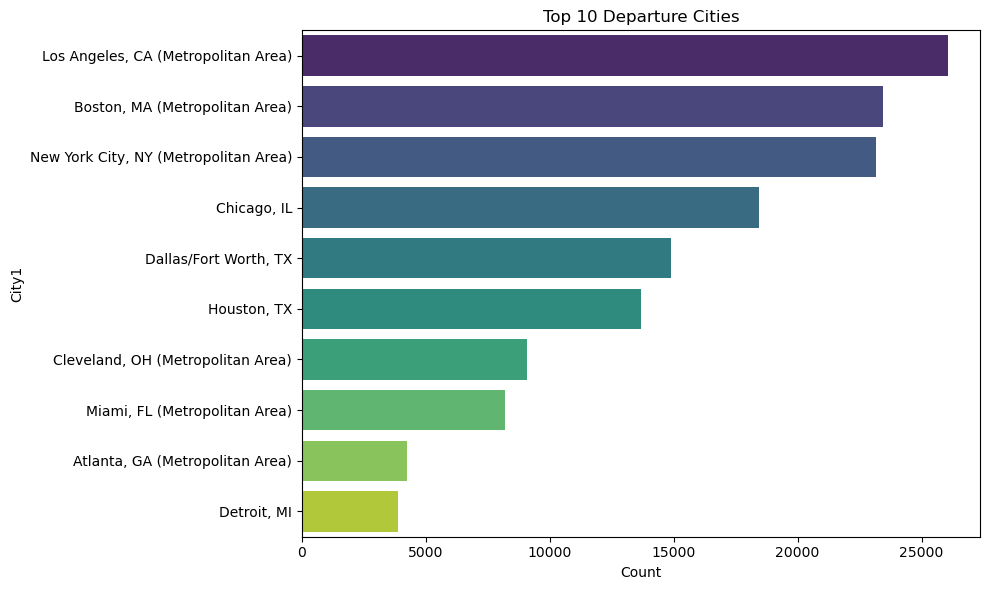

```python
# Visualizing categorical columns
df_top_cities = df.groupby('city1').size().nlargest(10).reset_index(name='counts')

plt.figure(figsize=(10, 6))
sns.barplot(data=df_top_cities, x='counts', y='city1', palette="viridis")
plt.title('Top 10 Departure Cities')
plt.xlabel('Count')
plt.ylabel('City1')
plt.tight_layout()
plt.show()
```

[figure not shown]

```python
# Visualizing categorical columns
df_top_cities = df.groupby('city2').size().nlargest(10).reset_index(name='counts')

plt.figure(figsize=(10, 6))
sns.barplot(data=df_top_cities, x='counts', y='city2', palette="viridis")
plt.title('Top 10 Departure Cities')
plt.xlabel('Count')
plt.ylabel('City2')
plt.tight_layout()
plt.show()
```

**Taking only the Numerical columns**

```python
numeric_cols = df.select_dtypes(include=['float64', 'int64'])

corr_matrix = numeric_cols.corr()
```

```python
corr= numeric_cols.corr()

corr
```

|  | Year | quarter | citymarketid_1 | citymarketid_2 | airportid_1 | airportid_2 | nsmiles | passengers | fare | large_ms | fare_lg | lf_ms | fare_low |
| --- | --- | --- | --- | --- | --- | --- | --- | --- | --- | --- | --- | --- | --- |
| Year | 1.000000 | 0.006125 | -0.000373 | -0.007119 | -0.009018 | -0.016622 | 0.018843 | 0.086214 | 0.151058 | 0.105065 | 0.154486 | 0.104044 | 0.174176 |
| quarter | 0.006125 | 1.000000 | 0.000384 | 0.003282 | 0.000650 | 0.000613 | 0.000205 | 0.016498 | -0.026186 | -0.000970 | -0.024448 | -0.000439 | -0.015893 |
| citymarketid_1 | -0.000373 | 0.000384 | 1.000000 | 0.007237 | 0.526658 | 0.061771 | 0.104284 | -0.043699 | 0.044420 | -0.118802 | 0.036881 | -0.056376 | 0.033287 |
| citymarketid_2 | -0.007119 | 0.003282 | 0.007237 | 1.000000 | 0.043398 | 0.537673 | 0.091133 | -0.090974 | 0.014113 | -0.024295 | 0.009559 | 0.021379 | 0.029091 |
| airportid_1 | -0.009018 | 0.000650 | 0.526658 | 0.043398 | 1.000000 | 0.067267 | 0.090738 | -0.015663 | 0.035840 | -0.103997 | 0.026957 | -0.035898 | 0.038116 |
| airportid_2 | -0.016622 | 0.000613 | 0.061771 | 0.537673 | 0.067267 | 1.000000 | 0.182279 | -0.017792 | 0.053326 | -0.084816 | 0.046012 | -0.022194 | 0.055831 |
| nsmiles | 0.018843 | 0.000205 | 0.104284 | 0.091133 | 0.090738 | 0.182279 | 1.000000 | -0.079008 | 0.500407 | -0.399184 | 0.481680 | -0.252122 | 0.415104 |
| passengers | 0.086214 | 0.016498 | -0.043699 | -0.090974 | -0.015663 | -0.017792 | -0.079008 | 1.000000 | -0.171460 | -0.077607 | -0.126350 | -0.121795 | -0.204582 |
| fare | 0.151058 | -0.026186 | 0.044420 | 0.014113 | 0.035840 | 0.053326 | 0.500407 | -0.171460 | 1.000000 | -0.175879 | 0.919441 | -0.183453 | 0.840893 |
| large_ms | 0.105065 | -0.000970 | -0.118802 | -0.024295 | -0.103997 | -0.084816 | -0.399184 | -0.077607 | -0.175879 | 1.000000 | -0.178372 | 0.532429 | -0.081836 |
| fare_lg | 0.154486 | -0.024448 | 0.036881 | 0.009559 | 0.026957 | 0.046012 | 0.481680 | -0.126350 | 0.919441 | -0.178372 | 1.000000 | -0.235258 | 0.827805 |
| lf_ms | 0.104044 | -0.000439 | -0.056376 | 0.021379 | -0.035898 | -0.022194 | -0.252122 | -0.121795 | -0.183453 | 0.532429 | -0.235258 | 1.000000 | 0.057488 |
| fare_low | 0.174176 | -0.015893 | 0.033287 | 0.029091 | 0.038116 | 0.055831 | 0.415104 | -0.204582 | 0.840893 | -0.081836 | 0.827805 | 0.057488 | 1.000000 |

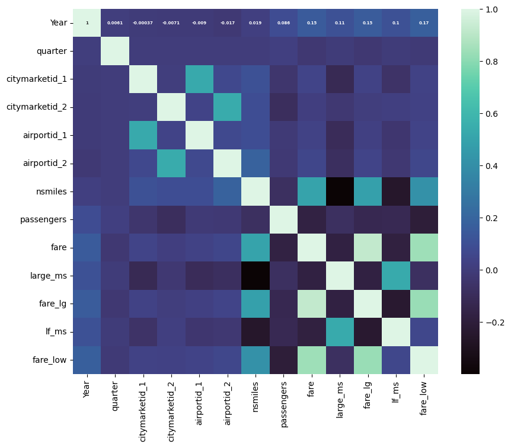

```python
plt.figure(figsize = (10,8))

sns.heatmap(data=corr,annot=True,cmap = "mako",annot_kws= {'fontsize':5, 'fontweight':'bold'},square= True)
```

**Bussiness Questions**

**1.Which routes have the highest average airfare?**

```python
# Group by city pairs and calculate the average fare
highest_fare_routes = df.groupby(['city1', 'city2']).agg(avg_fare=('fare', 'mean')).reset_index()

# Sort by average fare to get the routes with the highest fares
highest_fare_routes = highest_fare_routes.sort_values(by='avg_fare', ascending=False)

# Display the top 10 routes with the highest average fare
highest_fare_routes.head(10)
```

|  | city1 | city2 | avg_fare |
| --- | --- | --- | --- |
| 620 | Eagle, CO | Miami, FL (Metropolitan Area) | 430.639667 |
| 793 | Jackson, WY | New York City, NY (Metropolitan Area) | 425.305878 |
| 45 | Aspen, CO | New York City, NY (Metropolitan Area) | 418.618156 |
| 44 | Aspen, CO | Miami, FL (Metropolitan Area) | 398.735000 |
| 626 | El Paso, TX | Miami, FL (Metropolitan Area) | 391.130000 |
| 776 | Huntsville, AL | Los Angeles, CA (Metropolitan Area) | 372.231333 |
| 206 | Bozeman, MT | New York City, NY (Metropolitan Area) | 365.010625 |
| 621 | Eagle, CO | New York City, NY (Metropolitan Area) | 364.070526 |
| 1071 | New York City, NY (Metropolitan Area) | Palm Springs, CA | 355.134983 |
| 298 | Chicago, IL | Key West, FL | 349.176250 |

Analysis:The above table shows the which are higest fare of all the routes

**2.What is the most common city pair (route) in terms of passenger traffic?**

```python
# Group by city pairs and sum the number of passengers
most_common_routes = df.groupby(['city1', 'city2']).agg(total_passengers=('passengers', 'sum')).reset_index()

# Sort by total passengers to get the most common routes
most_common_routes = most_common_routes.sort_values(by='total_passengers', ascending=False)

# Display the top 10 routes with the highest number of passengers
most_common_routes.head(10)
```

|  | city1 | city2 | total_passengers |
| --- | --- | --- | --- |
| 932 | Los Angeles, CA (Metropolitan Area) | San Francisco, CA (Metropolitan Area) | 2145874 |
| 978 | Miami, FL (Metropolitan Area) | New York City, NY (Metropolitan Area) | 1610441 |
| 911 | Los Angeles, CA (Metropolitan Area) | New York City, NY (Metropolitan Area) | 1173016 |
| 1070 | New York City, NY (Metropolitan Area) | Orlando, FL | 1034797 |
| 314 | Chicago, IL | New York City, NY (Metropolitan Area) | 1019094 |
| 1087 | New York City, NY (Metropolitan Area) | San Francisco, CA (Metropolitan Area) | 833970 |
| 201 | Boston, MA (Metropolitan Area) | Washington, DC (Metropolitan Area) | 760250 |
| 60 | Atlanta, GA (Metropolitan Area) | New York City, NY (Metropolitan Area) | 742844 |
| 935 | Los Angeles, CA (Metropolitan Area) | Seattle, WA | 696162 |
| 847 | Las Vegas, NV | Los Angeles, CA (Metropolitan Area) | 687331 |

**3.Which airline has carried the most passengers overall?**

```python
# Group by carrier and sum the number of passengers
most_passengers_airline = df.groupby('carrier_lg').agg(total_passengers=('passengers', 'sum')).reset_index()

# Sort by total passengers to find the airline that has carried the most passengers
most_passengers_airline = most_passengers_airline.sort_values(by='total_passengers', ascending=False)

# Display the top airlines
most_passengers_airline.head(10)
```

|  | carrier_lg | total_passengers |
| --- | --- | --- |
| 57 | WN | 18472457 |
| 4 | AA | 12851640 |
| 51 | UA | 11204565 |
| 11 | DL | 10250494 |
| 9 | CO | 4070035 |
| 7 | B6 | 4050943 |
| 53 | US | 3986823 |
| 6 | AS | 2489260 |
| 30 | NW | 2028363 |
| 15 | FL | 630241 |

Analysis 3: Based on the provided data, WN (Southwest Airlines) has carried the most passengers overall, with a total of 18,472,457 passengers.

**4.What is the busiest airport based on the number of passengers?**

```python
# Group by airport and sum the number of passengers
busiest_airports = df.groupby('airport_1').agg(total_passengers=('passengers', 'sum')).reset_index()

# Sort by total passengers to find the busiest airports
busiest_airports = busiest_airports.sort_values(by='total_passengers', ascending=False)

# Display the top 10 busiest airports
busiest_airports.head(10)
```

|  | airport_1 | total_passengers |
| --- | --- | --- |
| 135 | ORD | 6339800 |
| 26 | BOS | 5249006 |
| 102 | LAX | 5054697 |
| 53 | DFW | 4145965 |
| 10 | ATL | 3734532 |
| 112 | MDW | 2697008 |
| 101 | LAS | 2412409 |
| 67 | FLL | 2237815 |
| 51 | DEN | 2141167 |
| 91 | IAH | 2043849 |

**5.Which routes are the longest in terms of miles traveled?**

```python
# Sort by the number of miles to find the longest routes
longest_routes = df[['city1', 'city2', 'nsmiles']].sort_values(by='nsmiles', ascending=False)

# Display the top 10 longest routes
longest_routes.head(10)
```

|  | city1 | city2 | nsmiles |
| --- | --- | --- | --- |
| 8149 | Miami, FL (Metropolitan Area) | Seattle, WA | 2724 |
| 233821 | Miami, FL (Metropolitan Area) | Seattle, WA | 2724 |
| 218576 | Miami, FL (Metropolitan Area) | Seattle, WA | 2724 |
| 172053 | Miami, FL (Metropolitan Area) | Seattle, WA | 2724 |
| 64146 | Miami, FL (Metropolitan Area) | Seattle, WA | 2724 |
| 183702 | Miami, FL (Metropolitan Area) | Seattle, WA | 2724 |
| 122979 | Miami, FL (Metropolitan Area) | Seattle, WA | 2724 |
| 186100 | Miami, FL (Metropolitan Area) | Seattle, WA | 2724 |
| 233822 | Miami, FL (Metropolitan Area) | Seattle, WA | 2724 |
| 31766 | Miami, FL (Metropolitan Area) | Seattle, WA | 2724 |

Analysis 5: The route between the Miami and Seattel city are the more miles than compare to other routes

**6.Which airlines offer the cheapest fares on average?**

```python
# Group by airline and calculate the average fare
cheapest_airlines = df.groupby('carrier_low').agg(avg_fare=('fare_low', 'mean')).reset_index()

# Sort by average fare to find the airlines with the cheapest fares
cheapest_airlines = cheapest_airlines.sort_values(by='avg_fare', ascending=True)

# Display the top 10 cheapest airlines
cheapest_airlines.head(20)
```

|  | carrier_low | avg_fare |
| --- | --- | --- |
| 4 | A7 | 58.480000 |
| 20 | HA | 65.630000 |
| 10 | C8 | 69.500000 |
| 27 | KS | 69.750000 |
| 31 | N5 | 84.290000 |
| 25 | KN | 84.743704 |
| 6 | AQ | 86.903036 |
| 53 | U2 | 91.077143 |
| 15 | EV | 91.127500 |
| 40 | P9 | 93.053535 |
| 62 | WV | 95.670494 |
| 69 | ZV | 96.200000 |
| 64 | XP | 98.244588 |
| 50 | TB | 98.559412 |
| 19 | G4 | 98.930639 |
| 65 | YV | 102.392222 |
| 1 | 5J | 104.010000 |
| 38 | OO | 106.582500 |
| 33 | NJ | 106.798133 |
| 14 | E9 | 107.692500 |

**7.Which quarter of the year tends to have the lowest average fares?**

```python
# Group by quarter and calculate the average fare
average_fare_by_quarter = df.groupby('quarter').agg(avg_fare=('fare', 'mean')).reset_index()

# Sort by average fare to find the quarter with the lowest fares
average_fare_by_quarter = average_fare_by_quarter.sort_values(by='avg_fare', ascending=True)

# Display the result
average_fare_by_quarter
```

|  | quarter | avg_fare |
| --- | --- | --- |
| 3 | 4 | 216.530589 |
| 2 | 3 | 216.692959 |
| 1 | 2 | 221.082159 |
| 0 | 1 | 221.486291 |

**8.How does airfare vary between nearby cities (under 500 miles) and distant cities (over 1000 miles)?**

```python
# Categorize routes as nearby (under 500 miles) and distant (over 1000 miles)
df['distance_category'] = pd.cut(df['nsmiles'], bins=[0, 500, 1000, df['nsmiles'].max()], labels=['Nearby', 'Mid-range', 'Distant'])

# Group by distance category and calculate the average fare
fare_by_distance = df.groupby('distance_category').agg(avg_fare=('fare', 'mean')).reset_index()

# Display the result
fare_by_distance
```

```
C:\Users\darshan gangappa\AppData\Local\Temp\ipykernel_36352\3386118124.py:5: FutureWarning: The default of observed=False is deprecated and will be changed to True in a future version of pandas. Pass observed=False to retain current behavior or observed=True to adopt the future default and silence …
  fare_by_distance = df.groupby('distance_category').agg(avg_fare=('fare', 'mean')).reset_index()
```

|  | distance_category | avg_fare |
| --- | --- | --- |
| 0 | Nearby | 172.196092 |
| 1 | Mid-range | 192.331704 |
| 2 | Distant | 251.566635 |